# Hechos estilizados

DLM

2025-02-04

#¿Qué es un hecho estilizado?

Un hecho estilizado es la aceptación de un suceso que ha sido observado, el cual se repite periodicamente.

Los hechos estilizados referentes al comportamiento del precio y del rendimiento de un activo que cotiza en una bolsa de valores, son los siguientes:

## Hecho estilizado 1:

Los precios de los activosy el valor de los protafolios siguen una caminata aleatoria.

Para verificar este hecho primero vamos a graficar una caminata aleatoria.

$$S_t = S_{t-1} + \epsilon$$
Donde $\epsilon$ tiene un comportamiento normal con media 0 y varianza 1

$$\epsilon \sim N(0,1)$$
$$E[\epsilon] = 0, \sigma^2 = 1$$
El comportamiento de $\epsilon$ también cumple con lo siguiente:

$$Cov[\epsilon_i,\epsilon_j]=0$$
Esto tiene implicaciones importantes: - No hay correlación entre los rendimientos de un periodo con el otro. Es decir, hay falta de memoria. - Esto determiina la formación eficiente de los precios.

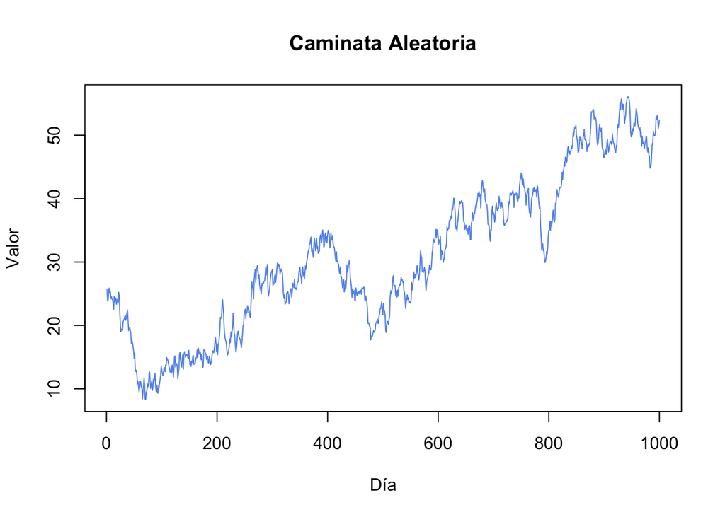

```r
n <- 1000
So <- 25
epsilon <- rnorm(n)
St <- So + cumsum(epsilon)
plot(St, type="l", xlab="Día", ylab="Valor", col="cornflowerblue", main="Caminata Aleatoria")
```

Vamos a comparar este comportamiento con el del precio de un activo.

```r
library(quantmod)
datos <- new.env()
ticker <- "GFNORTEO.MX"
getSymbols(ticker, env=datos)
```

```
## [1] "GFNORTEO.MX"
```

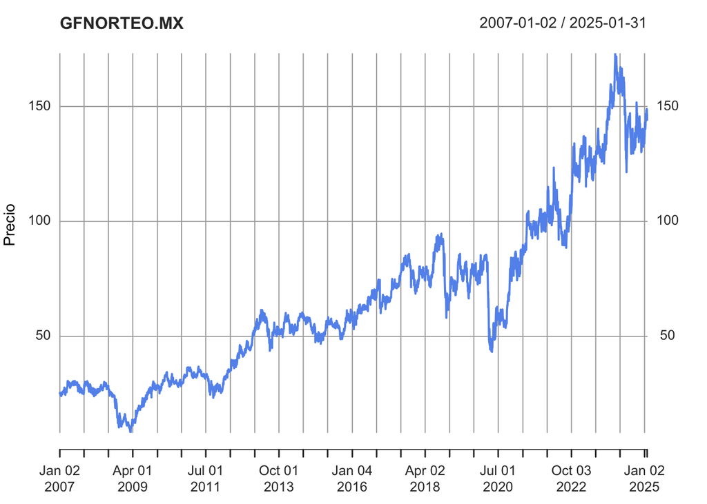

```r
precio <- datos[[ticker]][,6]

plot(precio, type="l", ylab="Precio", col="cornflowerblue", main=ticker)
```

## Hecho estilizado 2:

La distribución del rendimiento del precio tiene una forma aproximadamente “acampanada”.

Una característica del comportamiento del rendimiento es que cuando hacemos un histograma para ver su distribución, se observa una especie de campana con ciertas deformaciones. *Nota:* Recuerda que el comportamiento de campana hace referencia a la distribución normal.

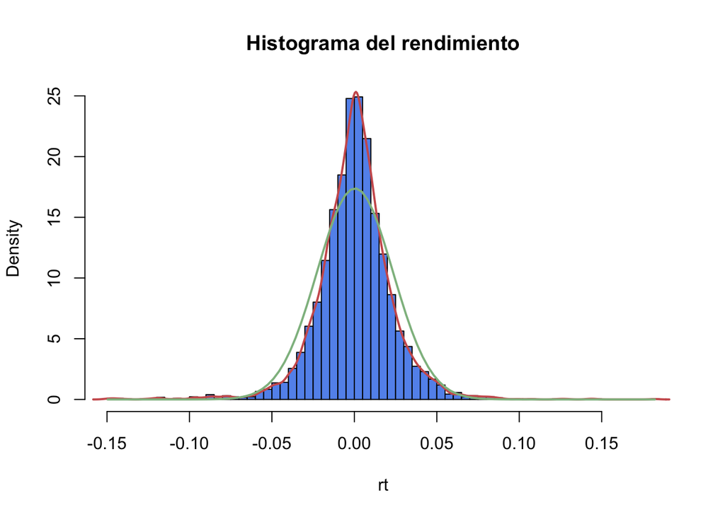

```r
rt <- na.omit(diff(log(precio)))
hist(rt, n=100, col="cornflowerblue", main="Histograma del rendimiento", prob=TRUE)
lines(density(rt), col="indianred", lwd=2)
xval <- seq(min(rt), max(rt), length.out=100)
lines(xval, dnorm(xval, mean=mean(rt), sd=sd(rt)), col="darkseagreen", lwd=2)
```

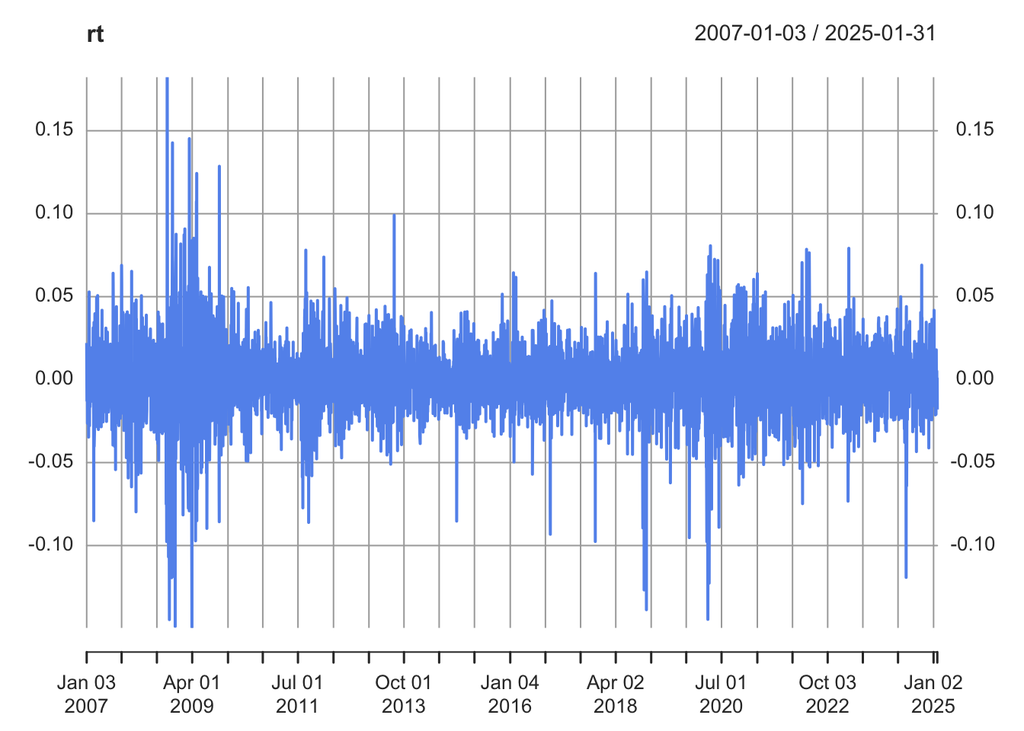

```r
plot(rt, col="cornflowerblue")
```

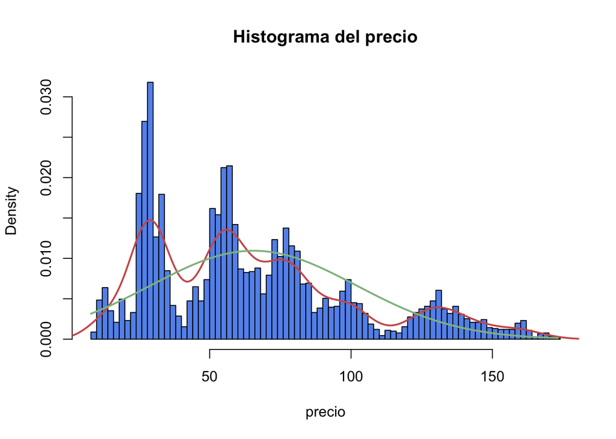

```r
hist(precio, n=100, col="cornflowerblue", main="Histograma del precio", prob=TRUE)
lines(density(precio), col="indianred", lwd=2)
xval <- seq(min(precio), max(precio), length.out=100)
lines(xval, dnorm(xval, mean=mean(precio), sd=sd(precio)), col="darkseagreen", lwd=2)
```

## Hecho estilizado 3:

Los rendimientos de los activos presentan volatilidad no constante y agrupada.

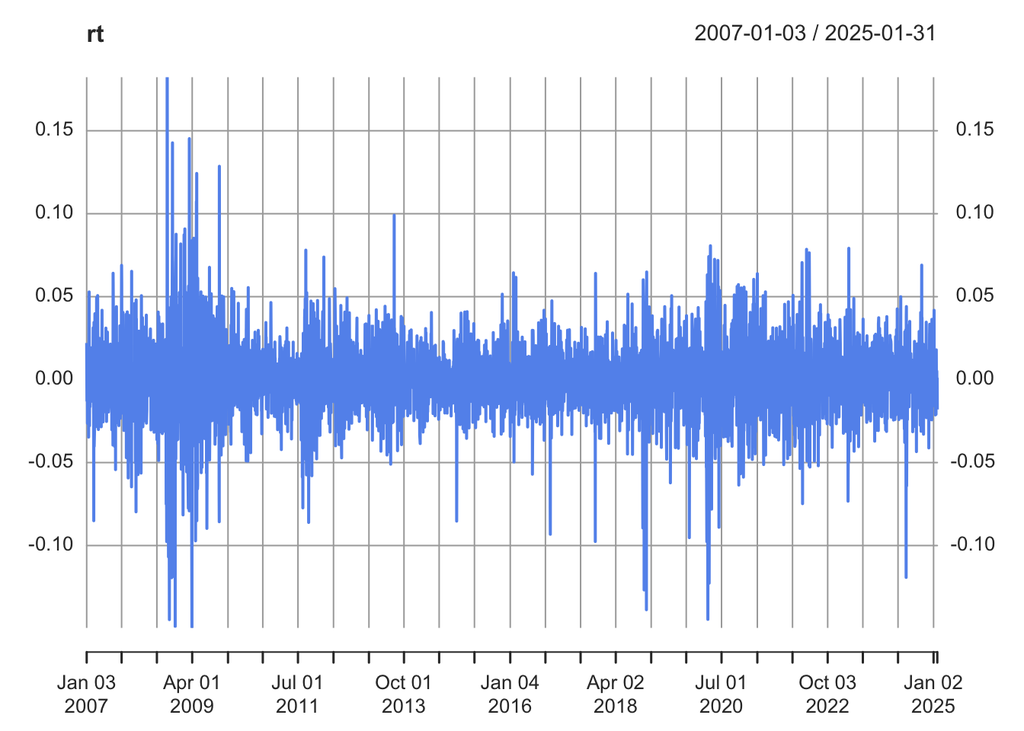

```r
plot(rt, col="cornflowerblue")
```

### Bandas de bollinger

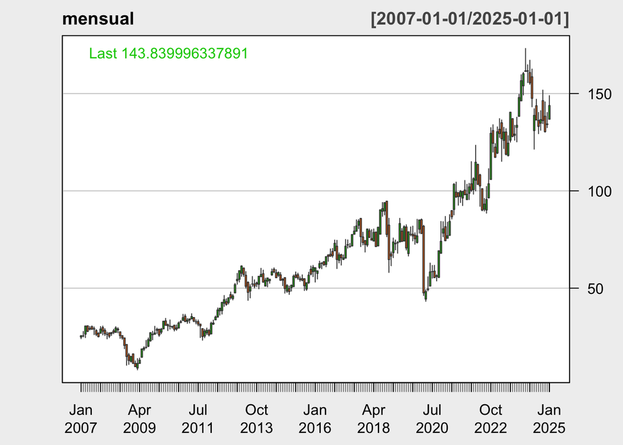

```r
mensual <- to.monthly(precio)
chartSeries(mensual, theme="white")
```

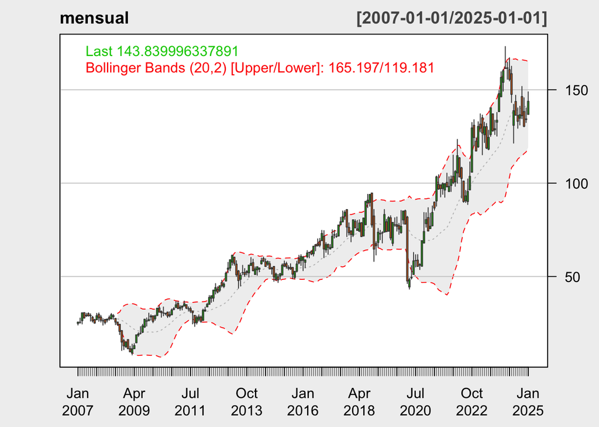

```r
addBBands()
```

En un mercado volatil las bandas de Bollinger se expanden, mientras que en un mercado menoos volatil las bandas se estrechan. Esto nos dice que la volatilidad no es constante y tiende a agruparse.

## Hecho estilizado 4:

La distribución de los rendimientos presenta leptocurtosis.

Este hecho nos dice que los rendimientos tienen un exceso de datos al rededor de la media (en exceso comparado con la distribución normal). Además, los rendimientos tienen colas pesadas.

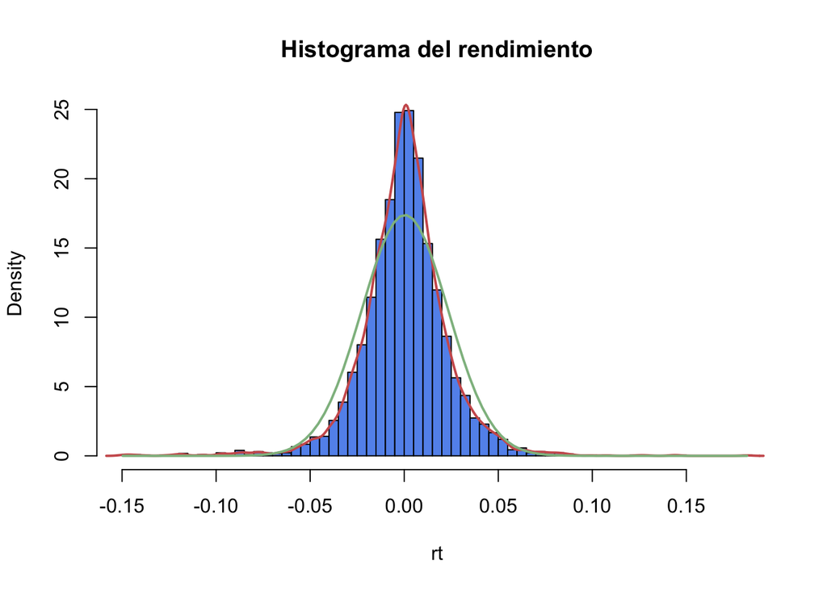

```r
rt <- na.omit(diff(log(precio)))
hist(rt, n=100, col="cornflowerblue", main="Histograma del rendimiento", prob=TRUE)
lines(density(rt), col="indianred", lwd=2)
xval <- seq(min(rt), max(rt), length.out=100)
lines(xval, dnorm(xval, mean=mean(rt), sd=sd(rt)), col="darkseagreen", lwd=2)
```

```r
min(rt)
```

```
## [1] -0.149636
```

```r
max(rt)
```

```
## [1] 0.1822695
```

```r
mean(rt)
```

```
## [1] 0.0003864265
```